# Kashihara_Ito_2020

### Edgeの重み (=偏相関係数) の正確性を検討 (Fig. S3)

※1行目のbootnet関数の中で，statistics = c(“edge”, “strength”, “closeness”, “betweenness”) というオプションを新たに指定していることに注意。bootnetパッケージのバージョン1.3では，オプションを指定しないとclosenessやbetweennessについての計算が実施されない仕様になっている。

```r
set.seed(2020) # 再現可能な分析結果を得るため，任意のシードを指定
boot1 <- bootnet(Network, nBoots = 2500, nCores =8,
                 statistics =   c("edge", "strength", "closeness", "betweenness"))
```

```
## Note: bootnet will store only the following statistics:  edge, strength, closeness, betweenness
```

```
## Estimating sample network...
```

```
## Estimating Network. Using package::function:
##   - qgraph::EBICglasso for EBIC model selection
##     - using glasso::glasso
##   - qgraph::cor_auto for correlation computation
##     - using lavaan::lavCor
```

```
## Bootstrapping...
```

```
## Computing statistics...
```

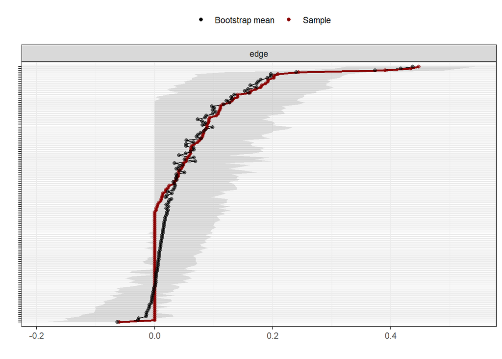

```r
plot(boot1, labels = FALSE, order = "sample")
```

### 中心性指標の安定性を検討 (Fig. S4)

```r
set.seed(2020) # 再現可能な分析結果を得るため，任意のシードを指定
boot2 <- bootnet(Network, nBoots = 2500, type = "case", nCores =8,
                 statistics =  c("strength", "closeness", "betweenness"))
```

```
## Note: bootnet will store only the following statistics:  strength, closeness, betweenness
```

```
## Estimating sample network...
```

```
## Estimating Network. Using package::function:
##   - qgraph::EBICglasso for EBIC model selection
##     - using glasso::glasso
##   - qgraph::cor_auto for correlation computation
##     - using lavaan::lavCor
```

```
## Bootstrapping...
```

```
## Computing statistics...
```

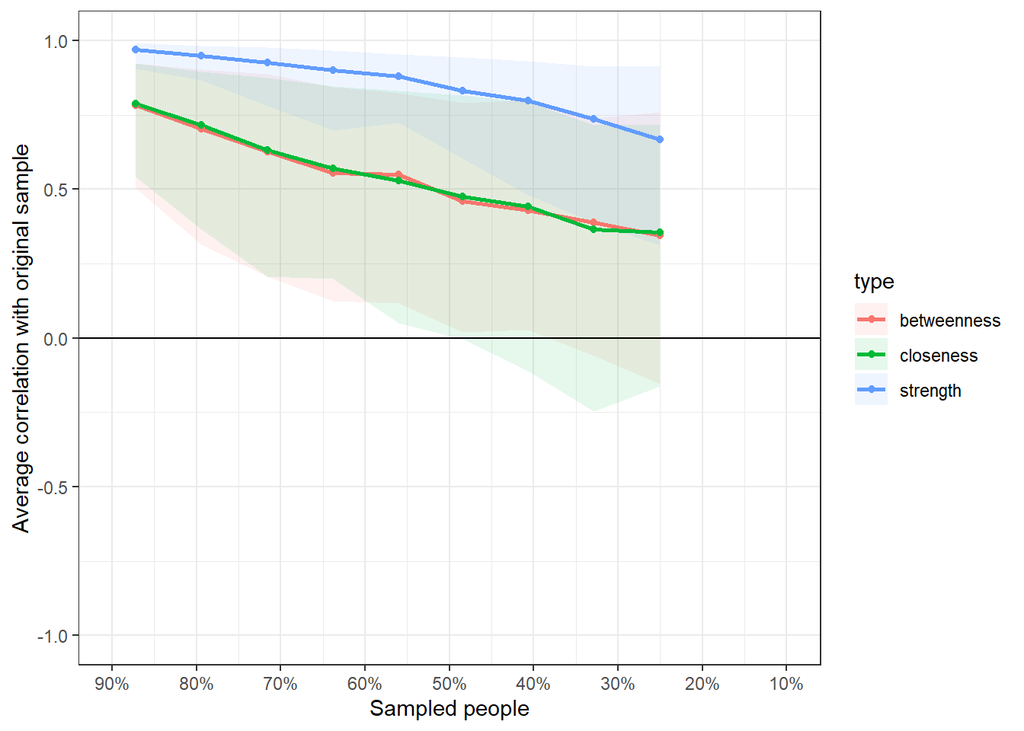

```r
plot(boot2, c("strength", "closeness", "betweenness"))
```

```r
corStability(boot2)
```

```
## === Correlation Stability Analysis ===
##
## Sampling levels tested:
##    nPerson Drop%   n
## 1       90  74.9 222
## 2      118  67.1 239
## 3      146  59.3 284
## 4      174  51.5 225
## 5      201  44.0 250
## 6      229  36.2 236
## 7      257  28.4 263
## 8      285  20.6 248
## 9      313  12.8 258
## 10     341   5.0 275
##
## Maximum drop proportions to retain correlation of 0.7 in at least 95% of the samples:
##
## betweenness: 0.05 (CS-coefficient is lowest level tested)
##   - For more accuracy, run bootnet(..., caseMin = 0, caseMax = 0.128)
##
## closeness: 0.05 (CS-coefficient is lowest level tested)
##   - For more accuracy, run bootnet(..., caseMin = 0, caseMax = 0.128)
##
## strength: 0.44
##   - For more accuracy, run bootnet(..., caseMin = 0.362, caseMax = 0.515)
##
## Accuracy can also be increased by increasing both 'nBoots' and 'caseN'.
```

### エッジ同士で，重みを一対比較 (Fig. S5)

```
## Expected significance level given number of bootstrap samples is approximately: 0.05
```

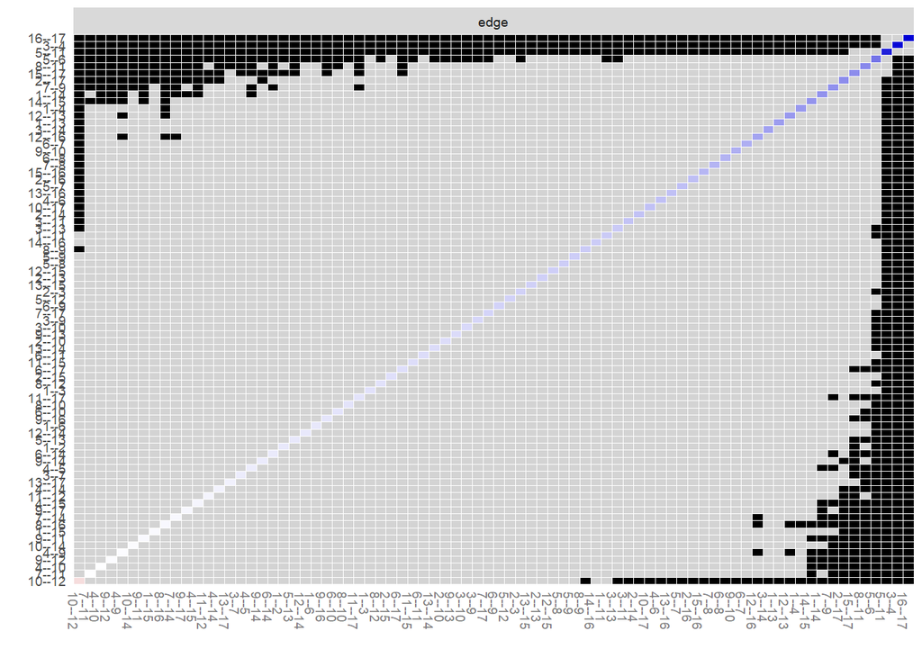

```r
plot(boot1, "edge", plot = "difference", onlyNonZero = TRUE, order = "sample")
```

### ノード同士で，strengthの大きさを一対比較 (Fig. S6)

下記コード内の“strength”を“closeness”や“betweenness”に書き換えれば，他の中心性指標についても同様の一対比較を実施できる。

```
## Expected significance level given number of bootstrap samples is approximately: 0.05
```

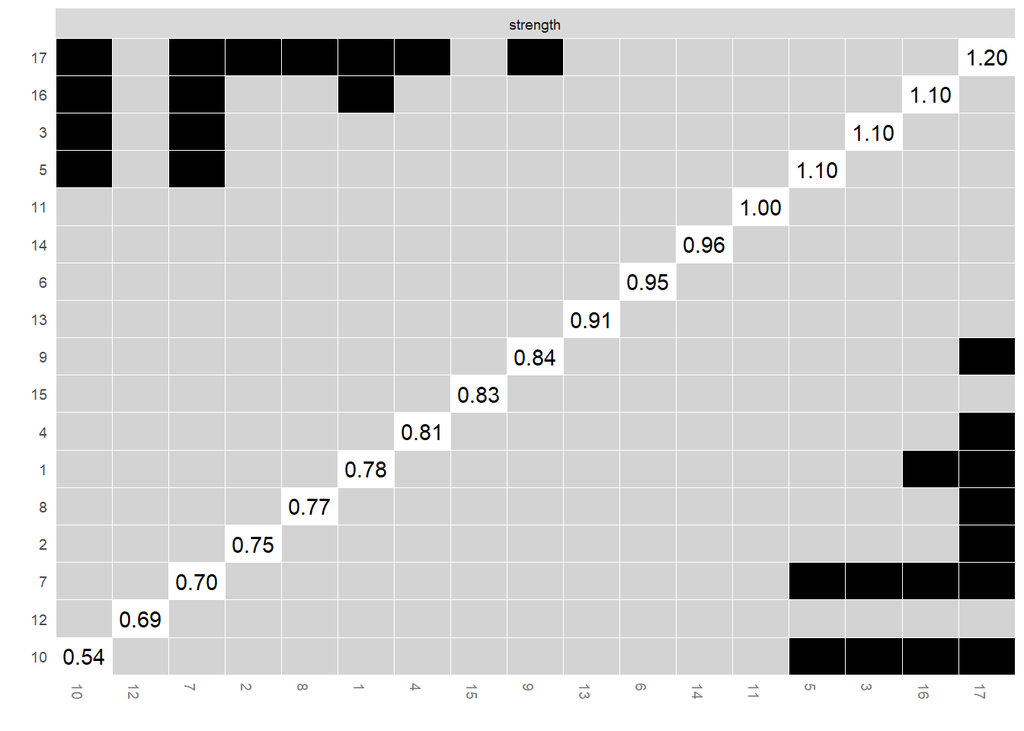

```r
plot(boot1,"strength", plot = "difference", order = "sample")
```